# VOCs Vendy

### Results t-test 2A

#### wilcoxon test for non normally distributed data - **treatment has a significant effect**.

## 2 B) an overall VOC variation between treatments - PCA

### Data manipulation

```r
data2B <- read.csv2("RStudio data 1.csv", dec = ",", header = TRUE, stringsAsFactors = FALSE)
data2B <- data2B %>% filter(Treatment %in% c("meja_ostruh", "meja_pid"))
data2B <- data2B %>%
  filter(Compound != "Total_Standard")

data2B$log_Value <- log(data2B$Value)

VOC_matrix <- data2B %>%
  select(ID, Compound, log_Value) %>%
  pivot_wider(names_from = Compound, values_from = log_Value) %>%
  left_join(data2B %>% select(ID, Treatment) %>% distinct(), by = "ID") %>%
  column_to_rownames(var = "ID")

VOC_matrix$Treatment <- as.factor(VOC_matrix$Treatment)
```

### PCA 2

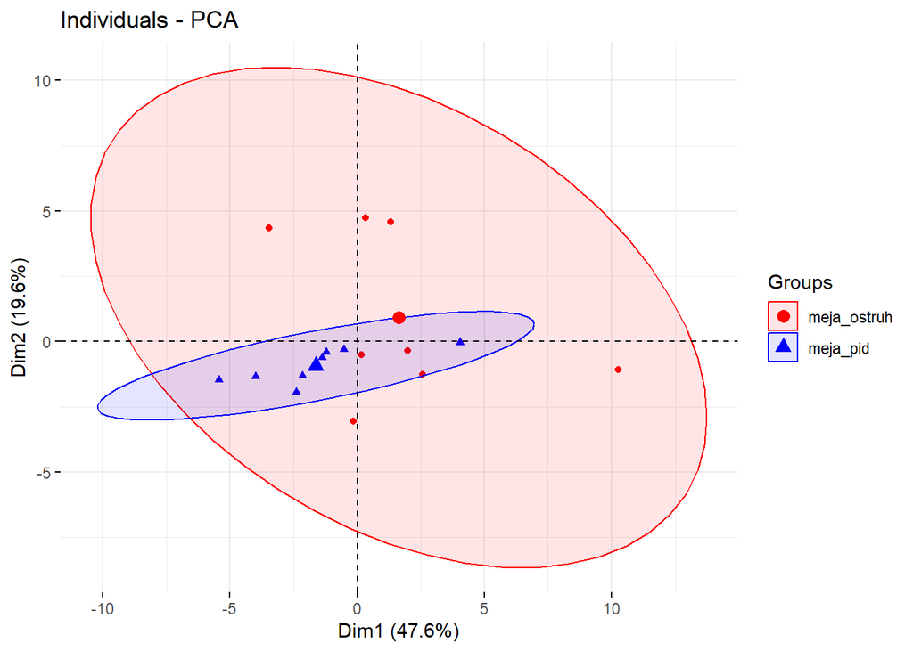

```r
pca_result <- PCA(VOC_matrix %>% select(-Treatment), scale.unit = TRUE, graph = FALSE)

palette_colors <- c("red", "blue")

fviz_pca_ind(pca_result,
             label = "none",
             habillage = VOC_matrix$Treatment,
             addEllipses = TRUE,
             ellipse.level = 0.95,
             palette = palette_colors)
```

### Results PCA

#### **Biological Interpretation:**

#### meja_ostruh appears to induce a stronger and more variable VOC response, which might be linked to plant defense activation. Meja_pid, in contrast, seems to reduce VOC diversity or stabilize the response, potentially suppressing certain compounds.

## C) Effect of treatment (species feeding) on individual compounds when MeJA treated

### Fitting model and variable selection

```r
model2B <- glmer(Value ~ Treatment * Compound + (1|ID), data = data2B, family = Gamma(link = "log"))
#convergence issue ->

model2B <- glmmTMB(Value ~ Treatment * Compound + (1|ID), data = data2B, family = Gamma(link = "log"))

reduced1 <- update(model2B, . ~ . - Compound)
reduced2 <- update(model2B, . ~ . - Treatment)
reduced3 <- update(model2B, . ~ . - Compound:Treatment)
Null <- glmmTMB(Value ~ 1 + (1|ID),
                data = data2B, family = Gamma(link = "log"))

# Compare models using AICc
models_list <- list(model2B, reduced1, reduced2, reduced3, Null)
model_selection <- model.sel(models_list, rank = AICc)
print(model_selection)
```

```
## Model selection table
##   cnd((Int)) dsp((Int)) cnd(Cmp) cnd(Trt) cnd(Cmp:Trt) df    logLik    AICc
## 3      16.76          +        +                     + 56 -6435.947 13000.9
## 1      16.76          +        +        +            + 56 -6435.947 13000.9
## 2      16.76          +                 +            + 56 -6435.947 13000.9
## 4      16.48          +        +        +              30 -6468.469 13001.6
## 5      15.13          +                                 3 -6838.631 13683.3
##    delta weight
## 3   0.00  0.269
## 1   0.00  0.269
## 2   0.00  0.269
## 4   0.66  0.193
## 5 682.40  0.000
## Models ranked by AICc(x)
## Random terms (all models):
##   cond(1 | ID)
```

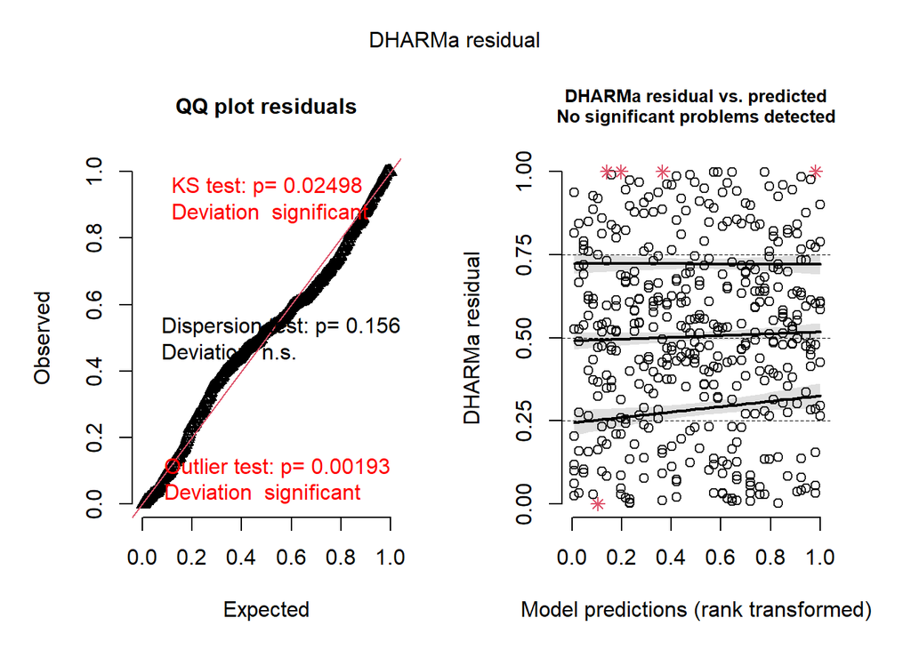

```r
simulationOutput <- simulateResiduals(fittedModel = model2B, n = 1000)
plot(simulationOutput)
```

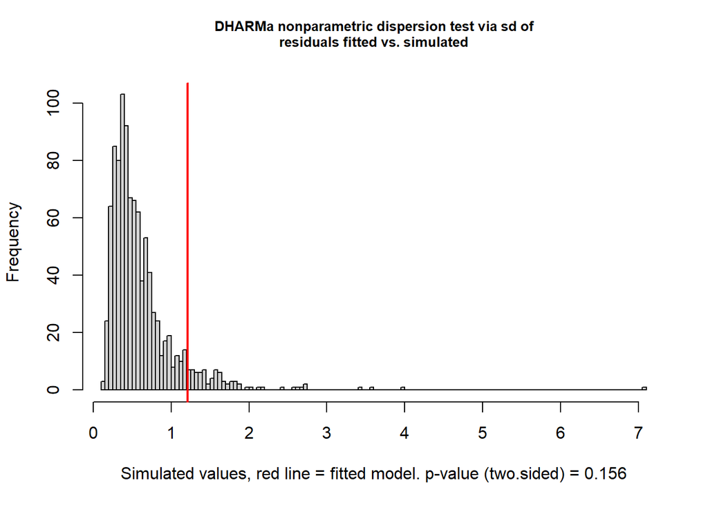

```
##
##  DHARMa nonparametric dispersion test via sd of residuals fitted vs.
##  simulated
##
## data:  simulationOutput
## dispersion = 1.9849, p-value = 0.156
## alternative hypothesis: two.sided
```

```r
testDispersion(simulationOutput)
```

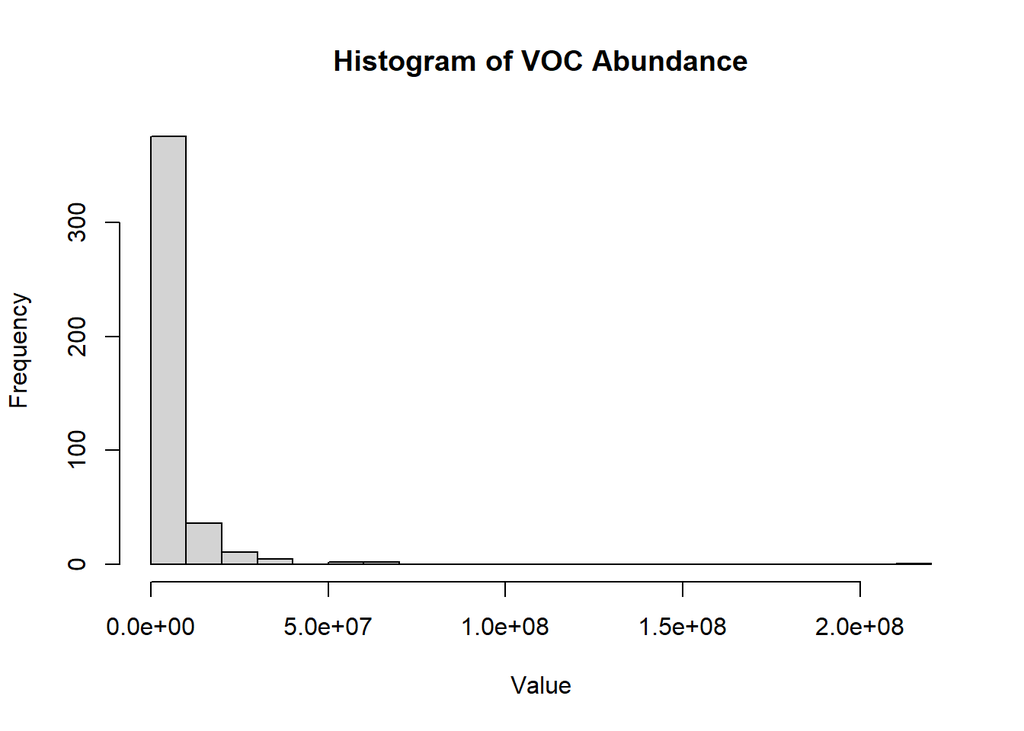

```r
hist(data2B$Value, breaks = 30, main = "Histogram of VOC Abundance", xlab = "Value")
```

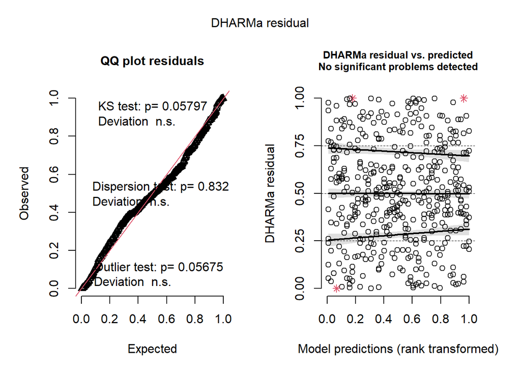

```r
# data are scewed -> use the log transformation

model_logT <- glmmTMB(log_Value ~ Treatment * Compound + (1|ID),
                      data = data2B, family = gaussian)
simulationOutput_logT <- simulateResiduals(fittedModel = model_logT, n = 1000)
plot(simulationOutput_logT)
```

```r
summary(model_logT)
```

```
##  Family: gaussian  ( identity )
## Formula:          log_Value ~ Treatment * Compound + (1 | ID)
## Data: data2B
##
##      AIC      BIC   logLik deviance df.resid
##   1228.8   1456.7   -558.4   1116.8      376
##
## Random effects:
##
## Conditional model:
##  Groups   Name        Variance Std.Dev.
##  ID       (Intercept) 0.2322   0.4818
##  Residual             0.7139   0.8449
## Number of obs: 432, groups:  ID, 16
##
## Dispersion estimate for gaussian family (sigma^2): 0.714
##
## Conditional model:
##                                                      Estimate Std. Error
## (Intercept)                                           16.3073     0.3439
## Treatmentmeja_pid                                     -1.1813     0.4863
## Compound2-Decen-1-ol_Standard                          0.3610     0.4225
## CompoundAcetic_acid_Standard                          -0.3759     0.4225
## CompoundButan-1-ol_Standard                           -0.1303     0.4225
## CompoundMethyl_salicilate_Standard                    -2.2742     0.4225
## CompoundUnknown_1_Standard                            -3.9237     0.4225
## CompoundUnknown_10_Standard                            0.6275     0.4225
## CompoundUnknown_11_Standard                           -4.6621     0.4225
## CompoundUnknown_12_Standard                           -0.2231     0.4225
## CompoundUnknown_13_Standard                           -2.3153     0.4225
## CompoundUnknown_14_Standard                           -2.2084     0.4225
## CompoundUnknown_15_Standard                           -2.4327     0.4225
## CompoundUnknown_16_Standard                           -0.9961     0.4225
## CompoundUnknown_17_Standard                           -1.6545     0.4225
## CompoundUnknown_18_Standard                           -4.3984     0.4225
## CompoundUnknown_19_Standard                           -4.8843     0.4225
## CompoundUnknown_2_Standard                            -3.3031     0.4225
## CompoundUnknown_20_Standard                           -2.4415     0.4225
## CompoundUnknown_21_Standard                           -2.0767     0.4225
## CompoundUnknown_22_Standard                           -2.3139     0.4225
```

[output cut: 75 more lines]

```
## Treatmentmeja_pid:CompoundUnknown_18_Standard           0.52  0.60221
## Treatmentmeja_pid:CompoundUnknown_19_Standard           1.35  0.17630
## Treatmentmeja_pid:CompoundUnknown_2_Standard            1.39  0.16332
## Treatmentmeja_pid:CompoundUnknown_20_Standard           0.99  0.32194
## Treatmentmeja_pid:CompoundUnknown_21_Standard          -1.26  0.20627
## Treatmentmeja_pid:CompoundUnknown_22_Standard           0.74  0.45974
## Treatmentmeja_pid:CompoundUnknown_3_Standard            1.43  0.15257
## Treatmentmeja_pid:CompoundUnknown_4_Standard            1.17  0.24084
## Treatmentmeja_pid:CompoundUnknown_5_Standard            1.76  0.07842 .
## Treatmentmeja_pid:CompoundUnknown_6_Standard            1.82  0.06834 .
## Treatmentmeja_pid:CompoundUnknown_7_Standard            0.82  0.41391
## Treatmentmeja_pid:CompoundUnknown_8_Standard            2.76  0.00573 **
## Treatmentmeja_pid:CompoundUnknown_9_Standard            1.67  0.09463 .
## ---
## Signif. codes:  0 '***' 0.001 '**' 0.01 '*' 0.05 '.' 0.1 ' ' 1
```

```r
emmeans(model_logT, pairwise ~ Treatment, by = "Compound", type = "response")
```

```
## $emmeans
## Compound = (Z)-3-Hexen-1-ol_acetate_Standard:
##  Treatment   emmean    SE  df lower.CL upper.CL
##  meja_ostruh  16.31 0.344 376    15.63    16.98
##  meja_pid     15.13 0.344 376    14.45    15.80
##
## Compound = 2-Decen-1-ol_Standard:
##  Treatment   emmean    SE  df lower.CL upper.CL
##  meja_ostruh  16.67 0.344 376    15.99    17.34
##  meja_pid     15.65 0.344 376    14.97    16.32
##
## Compound = Acetic_acid_Standard:
##  Treatment   emmean    SE  df lower.CL upper.CL
##  meja_ostruh  15.93 0.344 376    15.26    16.61
##  meja_pid     15.24 0.344 376    14.56    15.91
##
## Compound = Butan-1-ol_Standard:
##  Treatment   emmean    SE  df lower.CL upper.CL
##  meja_ostruh  16.18 0.344 376    15.50    16.85
##  meja_pid     14.88 0.344 376    14.20    15.55
##
## Compound = Methyl_salicilate_Standard:
##  Treatment   emmean    SE  df lower.CL upper.CL
##  meja_ostruh  14.03 0.344 376    13.36    14.71
##  meja_pid     14.12 0.344 376    13.44    14.80
##
## Compound = Unknown_1_Standard:
##  Treatment   emmean    SE  df lower.CL upper.CL
##  meja_ostruh  12.38 0.344 376    11.71    13.06
##  meja_pid     10.57 0.344 376     9.90    11.25
##
## Compound = Unknown_10_Standard:
##  Treatment   emmean    SE  df lower.CL upper.CL
##  meja_ostruh  16.93 0.344 376    16.26    17.61
##  meja_pid     16.24 0.344 376    15.56    16.91
##
## Compound = Unknown_11_Standard:
##  Treatment   emmean    SE  df lower.CL upper.CL
##  meja_ostruh  11.65 0.344 376    10.97    12.32
##  meja_pid     11.45 0.344 376    10.77    12.12
```

[output cut: 191 more lines]

```
## Compound = Unknown_6_Standard:
##  contrast               estimate    SE  df t.ratio p.value
##  meja_ostruh - meja_pid   0.0923 0.486 376   0.190  0.8496
##
## Compound = Unknown_7_Standard:
##  contrast               estimate    SE  df t.ratio p.value
##  meja_ostruh - meja_pid   0.6931 0.486 376   1.425  0.1549
##
## Compound = Unknown_8_Standard:
##  contrast               estimate    SE  df t.ratio p.value
##  meja_ostruh - meja_pid  -0.4695 0.486 376  -0.965  0.3350
##
## Compound = Unknown_9_Standard:
##  contrast               estimate    SE  df t.ratio p.value
##  meja_ostruh - meja_pid   0.1827 0.486 376   0.376  0.7074
```